# Mini-Project-2

Emily and Stephanie

3/7/2018

This chunck loads the tidyverse:

```r
library(tidyverse)
```

[LINK TO MINI-PROJECT 2 DESCRIPTION](https://beanumber.github.io/sds192/mod_data.html)

This chunck loads all the files available for the project through:

```r
load("house_elections.rda")
load("candidates.rda")
load("committees.rda")
load("contributions.rda")
```

```r
NancyPelosi <- candidates %>%
  select(cand_id, cand_name, cand_party_affiliation) %>%
  filter(cand_name == 'PELOSI, NANCY')
```

Then we created a new dataset by joining Nancy Pelosi and contributions by using the left_join function.

```r
cand_contr <- left_join(NancyPelosi, contributions)
```

We next combined the candidates and contributions dataset we created with committees and selected the following columns: candidate ID, candidate name, candidate party affiliation, name, transaction amount and committee party affiliation. Then we created a new column that was the sum of all transactions and used the distinct() function to remove redundancies in the rows. We then arranged them in descending order by sum and took the top 5 observations. This was done in order to obtain a table that had the highest contributing committees for Nancy Pelosi.

```r
cand_contr_comm <- left_join(cand_contr, committees) %>%
  select(cand_id, cand_name, cand_party_affiliation, name, transaction_amt, cmte_party_affiliation) %>%
  group_by(name) %>%
  mutate(sum = sum(transaction_amt)) %>%
  select(cand_id, cand_name, cand_party_affiliation, name, cmte_party_affiliation, sum) %>%
  distinct(sum,cand_id, cand_name, cand_party_affiliation, name, cmte_party_affiliation) %>%
  arrange(desc(sum)) %>%
  head(5)
```

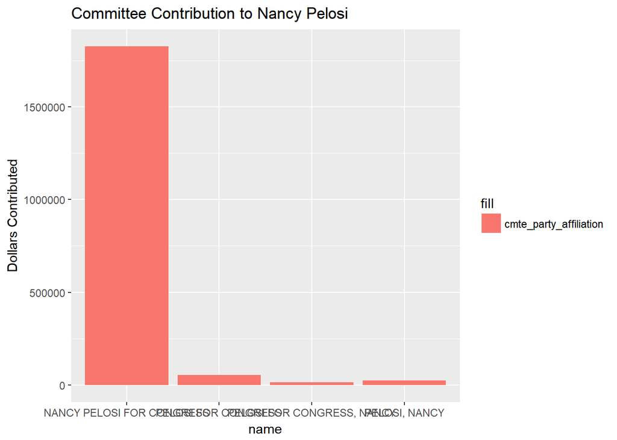

```r
ggplot(cand_contr_comm, aes(x=name, y=sum, fill="cmte_party_affiliation"))+
  geom_histogram(stat="identity") +
  labs(y="Dollars Contributed", title="Committee Contribution to Nancy Pelosi")
```

In the next code chunk we made a large table that joined the data by candidates.

```r
cand_contr_start <- candidates %>%
  select(cand_id,cand_name, cand_party_affiliation)
```

```r
cand_contrULTRA <- left_join(cand_contr_start, contributions)
```

Then, we created a master list with all candidates, candidate ID, candidates party affiliation, name of each donation, donation amount, and the type of organization each donation is from.

```r
cand_cantrULTRA2 <- left_join(cand_contrULTRA, committees) %>%
  select(cand_id, cand_name, cand_party_affiliation, name, transaction_amt, entity_type, cmte_party_affiliation) %>%
  group_by(name) %>%
  mutate(sum = sum(transaction_amt)) %>%
  select(cand_id, cand_name, cand_party_affiliation, name, cmte_party_affiliation, sum) %>%
  distinct(sum,cand_id, cand_name, cand_party_affiliation, name, cmte_party_affiliation)
```

The function below makes the desired graph for any candidate. Choosing any candidate and running it through the function “top_5” produces a graphic that shows the top 5 contributing committees.

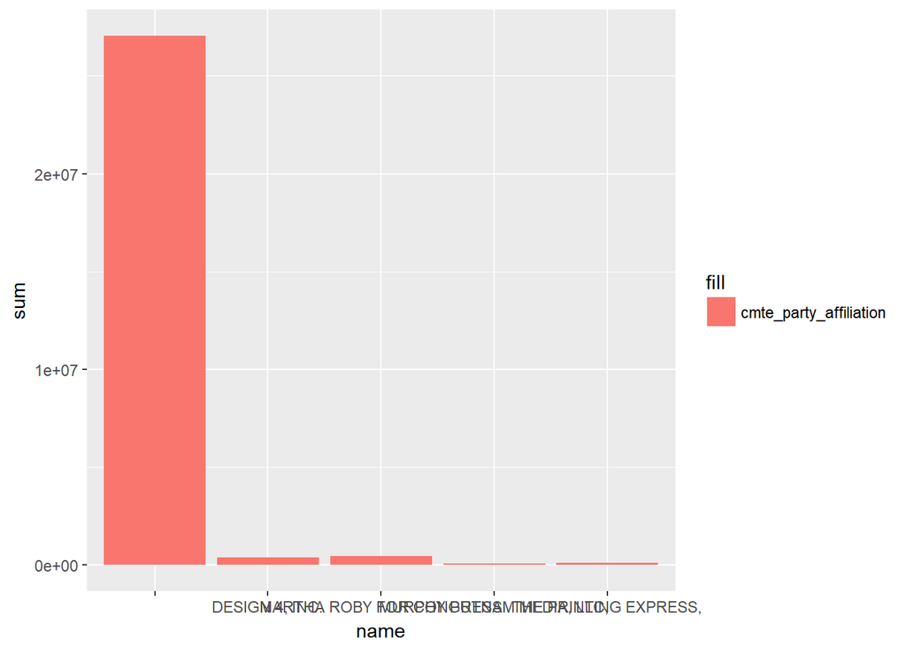

```r
top_5 <- function(name_arg) {
  plot_data <- cand_cantrULTRA2 %>%
    filter(cand_name == name_arg) %>%
    arrange(desc(sum)) %>%
    head(5)
  ggplot(plot_data,  aes(x=name, y=sum, fill="cmte_party_affiliation"))+
    geom_histogram(stat="identity")
}


ROBY <- top_5( "ROBY, MARTHA")
ROBY
```

[^1]

[^1]: [This is the link to the github repository](https://github.com/EmilyGrote/sds192-mp2.git)